# Project Python Foundations: FoodHub Data Analysis

**Marks: 60**

### Context

The number of restaurants in New York is increasing day by day. Lots of students and busy professionals rely on those restaurants due to their hectic lifestyles. Online food delivery service is a great option for them. It provides them with good food from their favorite restaurants. A food aggregator company FoodHub offers access to multiple restaurants through a single smartphone app.

The app allows the restaurants to receive a direct online order from a customer. The app assigns a delivery person from the company to pick up the order after it is confirmed by the restaurant. The delivery person then uses the map to reach the restaurant and waits for the food package. Once the food package is handed over to the delivery person, he/she confirms the pick-up in the app and travels to the customer's location to deliver the food. The delivery person confirms the drop-off in the app after delivering the food package to the customer. The customer can rate the order in the app. The food aggregator earns money by collecting a fixed margin of the delivery order from the restaurants.

### Objective

The food aggregator company has stored the data of the different orders made by the registered customers in their online portal. They want to analyze the data to get a fair idea about the demand of different restaurants which will help them in enhancing their customer experience. Suppose you are hired as a Data Scientist in this company and the Data Science team has shared some of the key questions that need to be answered. Perform the data analysis to find answers to these questions that will help the company to improve the business.

### Data Description

The data contains the different data related to a food order. The detailed data dictionary is given below.

### Data Dictionary

- order_id: Unique ID of the order
- customer_id: ID of the customer who ordered the food
- restaurant_name: Name of the restaurant
- cuisine_type: Cuisine ordered by the customer
- cost: Cost of the order
- day_of_the_week: Indicates whether the order is placed on a weekday or weekend (The weekday is from Monday to Friday and the weekend is Saturday and Sunday)
- rating: Rating given by the customer out of 5
- food_preparation_time: Time (in minutes) taken by the restaurant to prepare the food. This is calculated by taking the difference between the timestamps of the restaurant's order confirmation and the delivery person's pick-up confirmation.
- delivery_time: Time (in minutes) taken by the delivery person to deliver the food package. This is calculated by taking the difference between the timestamps of the delivery person's pick-up confirmation and drop-off information

### Let us start by importing the required libraries

```python
# import libraries for data manipulation
import numpy as np
import pandas as pd

# import libraries for data visualization
import matplotlib.pyplot as plt
import seaborn as sns
```

### Understanding the structure of the data

```python
# uncomment and run the following lines for Google Colab
# from google.colab import drive
# drive.mount('/content/drive')
```

```python
# read the data
df = pd.read_csv('/Users/jules/Programming Cert/Python Week 4/foodhub_order.csv')
# returns the first 5 rows
df.head()
```

|  | order_id | customer_id | restaurant_name | cuisine_type | cost_of_the_order | day_of_the_week | rating | food_preparation_time | delivery_time |
| --- | --- | --- | --- | --- | --- | --- | --- | --- | --- |
| 0 | 1477147 | 337525 | Hangawi | Korean | 30.75 | Weekend | Not given | 25 | 20 |
| 1 | 1477685 | 358141 | Blue Ribbon Sushi Izakaya | Japanese | 12.08 | Weekend | Not given | 25 | 23 |
| 2 | 1477070 | 66393 | Cafe Habana | Mexican | 12.23 | Weekday | 5 | 23 | 28 |
| 3 | 1477334 | 106968 | Blue Ribbon Fried Chicken | American | 29.20 | Weekend | 3 | 25 | 15 |
| 4 | 1478249 | 76942 | Dirty Bird to Go | American | 11.59 | Weekday | 4 | 25 | 24 |

#### Observations:

The DataFrame has 9 columns as mentioned in the Data Dictionary. Data in each row corresponds to the order placed by a customer.

### **Question 1:** How many rows and columns are present in the data? [0.5 mark]

```python
#returns the columns and rows in data set
df.shape
```

```
(1898, 9)
```

#### Observations:

There are 1898 rows and 9 columns.

### **Question 2:** What are the datatypes of the different columns in the dataset? (The info() function can be used) [0.5 mark]

```python
#returns a summary of the DataFrame
df.info()
```

```
<class 'pandas.core.frame.DataFrame'>
RangeIndex: 1898 entries, 0 to 1897
Data columns (total 9 columns):
 #   Column                 Non-Null Count  Dtype
---  ------                 --------------  -----
 0   order_id               1898 non-null   int64
 1   customer_id            1898 non-null   int64
 2   restaurant_name        1898 non-null   object
 3   cuisine_type           1898 non-null   object
 4   cost_of_the_order      1898 non-null   float64
 5   day_of_the_week        1898 non-null   object
 6   rating                 1898 non-null   object
 7   food_preparation_time  1898 non-null   int64
 8   delivery_time          1898 non-null   int64
dtypes: float64(1), int64(4), object(4)
memory usage: 133.6+ KB
```

#### Observations:

The datatypes of the different columns consist of 4 intergers, 1 floats and 4 objects. Rating needs to be converted to float rather than object type. Order_id and Customer_id do not appear to be needed as a numerical value and should be converted into object type. Order_id and Customer_id are used more so as an identifier for a customer or order.

```python
#Replacing Not given to a numerical value of 0

df['rating']=df['rating'].replace(['Not given'],0)

#Changing rating from an object type to a float. As well as changing order_id and customer_id from int64 to obj
df['rating']=df['rating'].astype(float)

df['order_id']=df['order_id'].astype(object)

df['customer_id']=df['customer_id'].astype(object)

df.info()

#creating a copy of the dataframe
data=df.copy()
```

```
<class 'pandas.core.frame.DataFrame'>
RangeIndex: 1898 entries, 0 to 1897
Data columns (total 9 columns):
 #   Column                 Non-Null Count  Dtype
---  ------                 --------------  -----
 0   order_id               1898 non-null   object
 1   customer_id            1898 non-null   object
 2   restaurant_name        1898 non-null   object
 3   cuisine_type           1898 non-null   object
 4   cost_of_the_order      1898 non-null   float64
 5   day_of_the_week        1898 non-null   object
 6   rating                 1898 non-null   float64
 7   food_preparation_time  1898 non-null   int64
 8   delivery_time          1898 non-null   int64
dtypes: float64(2), int64(2), object(5)
memory usage: 133.6+ KB
```

### **Question 3:** Are there any missing values in the data? If yes, treat them using an appropriate method. [1 mark]

```python
#Returns any null (missing) values in the data
df.isnull().sum()
```

```
order_id                 0
customer_id              0
restaurant_name          0
cuisine_type             0
cost_of_the_order        0
day_of_the_week          0
rating                   0
food_preparation_time    0
delivery_time            0
dtype: int64
```

#### Observations:

There appear to be 0 missing values in the data set given

### **Question 4:** Check the statistical summary of the data. What is the minimum, average, and maximum time it takes for food to be prepared once an order is placed? [2 marks]

```python
#Gives the statistical summary of the data
df.describe()
```

|  | cost_of_the_order | rating | food_preparation_time | delivery_time |
| --- | --- | --- | --- | --- |
| count | 1898.000000 | 1898.000000 | 1898.000000 | 1898.000000 |
| mean | 16.498851 | 2.659642 | 27.371970 | 24.161749 |
| std | 7.483812 | 2.195280 | 4.632481 | 4.972637 |
| min | 4.470000 | 0.000000 | 20.000000 | 15.000000 |
| 25% | 12.080000 | 0.000000 | 23.000000 | 20.000000 |
| 50% | 14.140000 | 4.000000 | 27.000000 | 25.000000 |
| 75% | 22.297500 | 5.000000 | 31.000000 | 28.000000 |
| max | 35.410000 | 5.000000 | 35.000000 | 33.000000 |

#### Observations:

- Minimum time for food prep: 20 minutes
- Average time for food prep: 27.37 minutes
- Maximum time for food prep: 35 minutes

### **Question 5:** How many orders are not rated? [1 mark]

```python
#Checking the counts for each value given in 'rating' to find orders not rated
df['rating'].value_counts()
```

```
0.0    736
5.0    588
4.0    386
3.0    188
Name: rating, dtype: int64
```

#### Observations:

There are 736 orders that are not rated inside our data set

### Exploratory Data Analysis (EDA)

### **Question 6:** Explore all the variables and provide observations on their distributions. (Generally, histograms, boxplots, countplots, etc. are used for univariate exploration.) [9 marks]

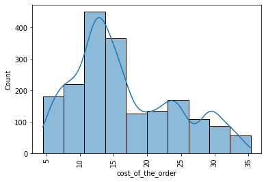

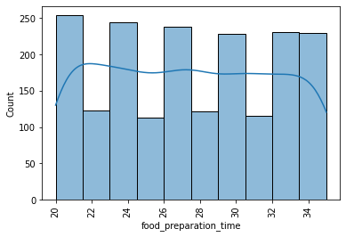

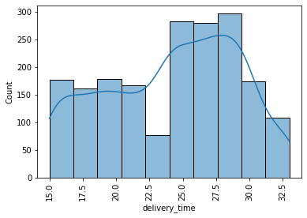

```python
#Created a variable that contains all numerical variables in the data
num_col=['cost_of_the_order','food_preparation_time','delivery_time']

#For loop that prints all histplots for the variable, as well as plot the KDE for each graph with the exception for rating
for column in num_col:
        sns.histplot(data=df,x=column,bins=10,kde=True)
        plt.xticks(rotation=90)
        plt.show()
```

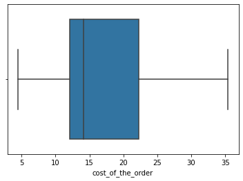

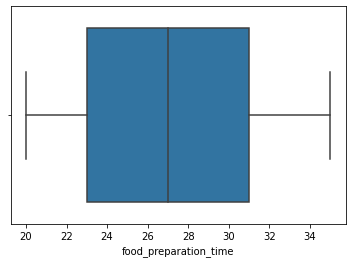

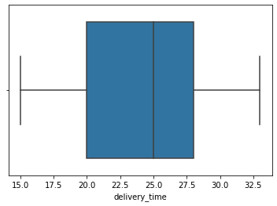

```python
#For loop that prints all boxplots for the variable with the exception for rating
for column in num_col:
        sns.boxplot(data=df,x=column)
        plt.show()
```

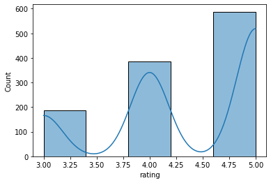

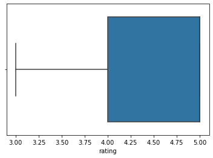

```python
#creating a variable that filters out all not rated orders
ratings=df[df['rating']>0]

#prints out a hisplot using the created variable above with 5 bins since rating only uses 5 value and plotting the KDE
sns.histplot(data=ratings,x='rating',bins=5,kde=True)
plt.show()
#prints out the boxplot for the variable above
sns.boxplot(data=ratings,x='rating')
plt.show()
```

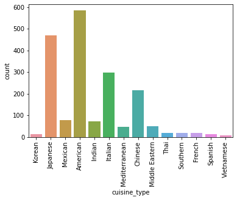

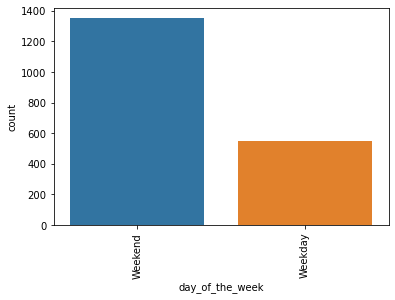

```python
#Creating a variable for categorical data
cat_col=['cuisine_type','day_of_the_week']

#For loop that prints the countplot for the variable above containing categorical columns
for column in cat_col:
    sns.countplot(data=df,x=column)
    plt.xticks(rotation=90)
    plt.show()
```

### **Question 7**: Which are the top 5 restaurants in terms of the number of orders received? [1 mark]

```python
#Finds the counts for the orders received for each restaurants,resets the index and returns the top 5 with head
df['restaurant_name'].value_counts().reset_index().head()
```

|  | index | restaurant_name |
| --- | --- | --- |
| 0 | Shake Shack | 219 |
| 1 | The Meatball Shop | 132 |
| 2 | Blue Ribbon Sushi | 119 |
| 3 | Blue Ribbon Fried Chicken | 96 |
| 4 | Parm | 68 |

#### Observations:

The top 5 restaurants in terms of the number of orders received are:

- Shake Shack 219
- The Meatball Shop 132
- Blue Ribbon Sushi 119
- Blue Ribbon Fried Chicken 96
- Parm 68

### **Question 8**: Which is the most popular cuisine on weekends? [1 mark]

```python
#Filters day_of_the_week for only Weekend data. Then groups and sorts the count of values in cuisine type to return the amount of orders of each cuisine on weekends
df[df['day_of_the_week']=='Weekend'].groupby('cuisine_type').count().sort_values('cuisine_type').reset_index()
```

|  | cuisine_type | order_id | customer_id | restaurant_name | cost_of_the_order | day_of_the_week | rating | food_preparation_time | delivery_time |
| --- | --- | --- | --- | --- | --- | --- | --- | --- | --- |
| 0 | American | 415 | 415 | 415 | 415 | 415 | 415 | 415 | 415 |
| 1 | Chinese | 163 | 163 | 163 | 163 | 163 | 163 | 163 | 163 |
| 2 | French | 13 | 13 | 13 | 13 | 13 | 13 | 13 | 13 |
| 3 | Indian | 49 | 49 | 49 | 49 | 49 | 49 | 49 | 49 |
| 4 | Italian | 207 | 207 | 207 | 207 | 207 | 207 | 207 | 207 |
| 5 | Japanese | 335 | 335 | 335 | 335 | 335 | 335 | 335 | 335 |
| 6 | Korean | 11 | 11 | 11 | 11 | 11 | 11 | 11 | 11 |
| 7 | Mediterranean | 32 | 32 | 32 | 32 | 32 | 32 | 32 | 32 |
| 8 | Mexican | 53 | 53 | 53 | 53 | 53 | 53 | 53 | 53 |
| 9 | Middle Eastern | 32 | 32 | 32 | 32 | 32 | 32 | 32 | 32 |
| 10 | Southern | 11 | 11 | 11 | 11 | 11 | 11 | 11 | 11 |
| 11 | Spanish | 11 | 11 | 11 | 11 | 11 | 11 | 11 | 11 |
| 12 | Thai | 15 | 15 | 15 | 15 | 15 | 15 | 15 | 15 |
| 13 | Vietnamese | 4 | 4 | 4 | 4 | 4 | 4 | 4 | 4 |

#### Observations:

American Cuisine is the most popular for the weekends which was ordered 415 times

### **Question 9**: What percentage of the orders cost more than 20 dollars? [2 marks]

```python
#filters for all orders that are greater than or equal $20
Orders_Over_20=(df['cost_of_the_order'][df['cost_of_the_order']>=20]).count()
```

```python
#Taking the numbers from the variable above and dividing it by the total number of all orders then multiplying by 100 to get percentage
Orders_Over_20/df['cost_of_the_order'].count()*100
```

```
29.24130663856691
```

#### Observations:

Around 29.24% of the orders cost more than $20

### **Question 10**: What is the mean order delivery time? [1 mark]

```python
#Finds the mean (average) for order delivery time
df['delivery_time'].mean()
```

```
24.161749209694417
```

#### Observations:

The mean order delivery time is around 24.16 minutes per order

### **Question 11:** The company has decided to give 20% discount vouchers to the top 5 most frequent customers. Find the IDs of these customers and the number of orders they placed. [1 mark]

```python
#grouping data by customer_id and sorting by the amount of orders each customer has placed. Then we are sorting the index from highest ordered to lowest,resetting the index and showing the top 10 customers
df.groupby('customer_id').count()[['order_id']].sort_values('order_id',ascending=False).reset_index().head(10)
```

|  | customer_id | order_id |
| --- | --- | --- |
| 0 | 52832 | 13 |
| 1 | 47440 | 10 |
| 2 | 83287 | 9 |
| 3 | 250494 | 8 |
| 4 | 65009 | 7 |
| 5 | 82041 | 7 |
| 6 | 259341 | 7 |
| 7 | 276192 | 7 |
| 8 | 60052 | 6 |
| 9 | 115213 | 6 |

#### Observations:

The top 5 most frequent customers by ID are below with exceptions due to the fact that there are 4 cutomers who also have the same number of orders placed for spot number 5 on the list.

- 52832 with 13 orders
- 47440 with 10 orders
- 83287 with 9 orders
- 250494 with 8 orders
- 65009 with 7 orders
- 82041 with 7 orders
- 259341 with 7 orders
- 276192 with 7 orders

### **Question 12**: Perform a multivariate analysis to explore relationships between the important variables in the dataset. (It is a good idea to explore relations between numerical variables as well as relations between numerical and categorical variables) [10 marks]

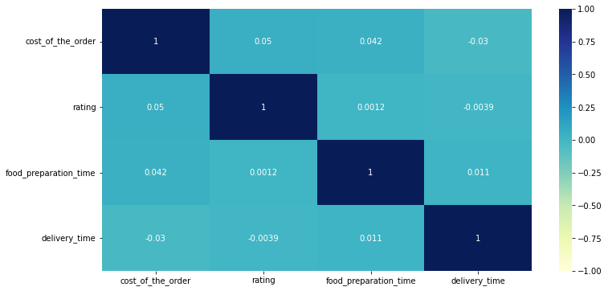

```python
#printing a heatmap showing the correlation betweem all numerical variables
plt.figure(figsize=(12,6))
sns.heatmap(df.corr(),annot=True,cmap='YlGnBu',vmin=-1,vmax=1)
plt.show()
```

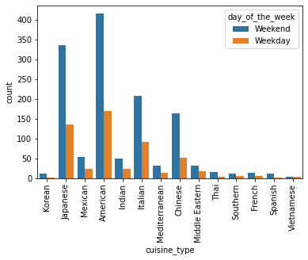

```python
#comparing the relationship between cusitine type and day of the week
sns.countplot(data=df,x='cuisine_type',hue='day_of_the_week')
plt.xticks(rotation=90)
plt.show()
```

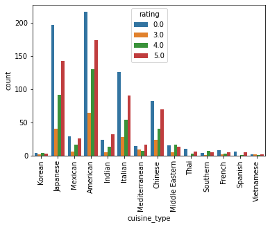

```python
#comparing the relationship between cusitine type and day of the week
sns.countplot(data=df,x='cuisine_type',hue='rating')
plt.xticks(rotation=90)
plt.show()
```

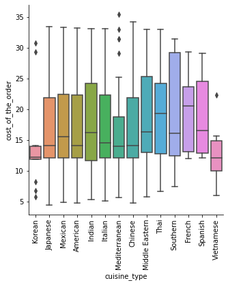

```python
#comparing the relationship between cost of order and cuisine type
sns.catplot(data=df,x='cuisine_type',y='cost_of_the_order',kind='box')
plt.xticks(rotation=90)
plt.show()
```

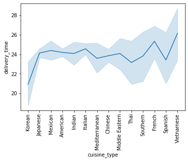

```python
#comparing the relationship between cuisine type and delivery time
sns.lineplot(data=df,x='cuisine_type',y='delivery_time')
plt.xticks(rotation=90)
plt.show()
```

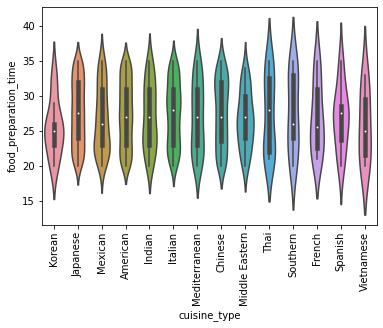

```python
#comparing the relationship between cuisine type and food_preparation_time
sns.violinplot(data=df,x='cuisine_type',y='food_preparation_time')
plt.xticks(rotation=90)
plt.show()
```

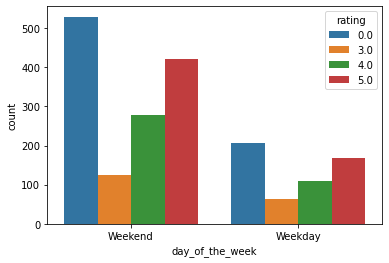

```python
#comparing the relationship between day of the week and rating
sns.countplot(data=df,x='day_of_the_week',hue='rating')
plt.show()
```

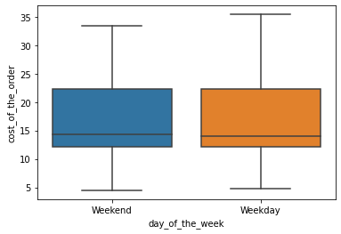

```python
#comparing the relationship between day of the week and cost of the order
sns.boxplot(data=df,x='day_of_the_week',y='cost_of_the_order')
plt.show()
```

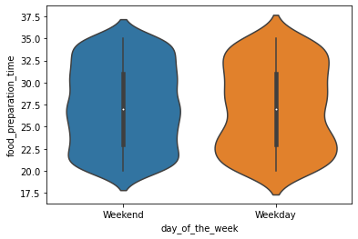

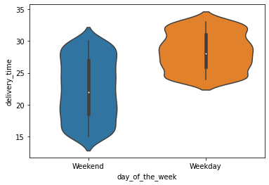

```python
#comparing the relationship between day of the week and food preparation time
sns.violinplot(data=df,x='day_of_the_week',y='food_preparation_time')
plt.show()
#comparing the relationship between day of the week and delivery time
sns.violinplot(data=df,x='day_of_the_week',y='delivery_time')
plt.show()
```

### **Question 13:** The company wants to provide a promotional offer in the advertisement of the restaurants. The condition to get the offer is that the restaurants must have a rating count of more than 50 and the average rating should be greater than 4. Find the restaurants fulfilling the criteria to get the promotional offer. [3 marks]

```python
#Creating a variable filtering out all ratings that are zero and calculating sum of ratings(1-5) over 50.
Rating_Over_50=df[['restaurant_name','rating']][df['rating']>0].groupby('restaurant_name').count()>50
```

```python
#Resetting index and showing True outcomes
Rating_Over_50.reset_index(inplace=True)
```

```python
#Creating a variable filtering out all ratings that are zero and calculating average of ratings(1-5) over 4.
Average_Over_4=df[['restaurant_name','rating']][df['rating']>0].groupby('restaurant_name').mean()>4
```

```python
#Resetting index and showing True outcomes
Average_Over_4.reset_index(inplace=True)
```

```python
#Merging both variables in a pandas dataframe showing only values that meet both conditions
pd.merge(Average_Over_4[Average_Over_4['rating']==True],Rating_Over_50[Rating_Over_50['rating']==True],on='restaurant_name')
```

|  | restaurant_name | rating_x | rating_y |
| --- | --- | --- | --- |
| 0 | Blue Ribbon Fried Chicken | True | True |
| 1 | Blue Ribbon Sushi | True | True |
| 2 | Shake Shack | True | True |
| 3 | The Meatball Shop | True | True |

#### Observations:

The restaurants that meet the criteria are as follows:

- Shake Shack
- The Meatball Shop
- Blue Ribbon Sushi
- Blue Ribbon Fried Chicken

### **Question 14:** The company charges the restaurant 25% on the orders having cost greater than 20 dollars and 15% on the orders having cost greater than 5 dollars. Find the net revenue generated by the company across all orders. [3 marks]

```python
#Creating an empty array to store values in revenue
Revenue=[]

#Creating variable containing the column cost_of_orders
cost=df['cost_of_the_order']

#For loop finding the sum of cost to meet the condition stated above
for i in range (len(cost)):
    if (cost[i]>5) & (cost[i]<20):
        Revenue.append(cost[i]*.15)
    elif (cost[i]>20):
        Revenue.append(cost[i]*.25)
    else:
        Revenue.append(0)

#sum of revenue
print(sum(Revenue))
```

```
6166.302999999994
```

#### Observations:

Total revenue generated across all orders is $6,166.30

### **Question 15:** The company wants to analyze the total time required to deliver the food. What percentage of orders take more than 60 minutes to get delivered from the time the order is placed? (The food has to be prepared and then delivered.) [2 marks]

```python
#creating a column Total time in data frame containing the sum of food prep time and delivery time
df['Total_Time']=df['food_preparation_time']+df['delivery_time']

#the count of the column Total Time
Order_Times=df['Total_Time'].count()

#the count of orders over 60 mins total time
Over_60_Min= df['Total_Time'][df['Total_Time']>60].count()

#percentage of orders that take over 60 min total
(Over_60_Min/Order_Times)*100
```

```
10.537407797681771
```

#### Observations:

10.54% of orders tend to take more than 60 minutes to get delivered from the time the order is placed. Which means around 89% of orders are being delivered under 60 minutes from time ordered.

### **Question 16:** The company wants to analyze the delivery time of the orders on weekdays and weekends. How does the mean delivery time vary during weekdays and weekends? [2 marks]

```python
#returns the average delivery time for the Weekday and Weekends
df.groupby('day_of_the_week')[['delivery_time']].mean()
```

| day_of_the_week | delivery_time |
| --- | --- |
| Weekday | 28.340037 |
| Weekend | 22.470022 |

#### Observations:

According to the data above the weekend times tend to be 6 minutes faster than your average weekday times. I believe this is due to the more people being inside their homes which garners less traffic on the roads.

### Recommendations:

- More customer interaction with rating their orders need to be handled to insure data will be less skewed in the future.
- Possibly more customer information as well to help give more depth to the data like age, sex, and occupation. To help further understand the target market. This data can be used to undestand the skewedness in the data possibly.
- For restaurants that a receiving less orders than others possible promotions or discounts can be ran in order to increase volume for said restaurants.
- It appears a lot of the revenue is generated over the weekend, finding a way to tap into the weekday market a little more will have a significant impact in the revenue generated. This again can be generated through promotions or faster delivery times that are closer to those of the weekend times.

```python
data.to_html('/Users/jules/Programming Cert/Python Project/PYF_Project_LearnerNotebook.html')
```